# Project 2: Data Mining, Classification, Prediction

### Cluster Analysis

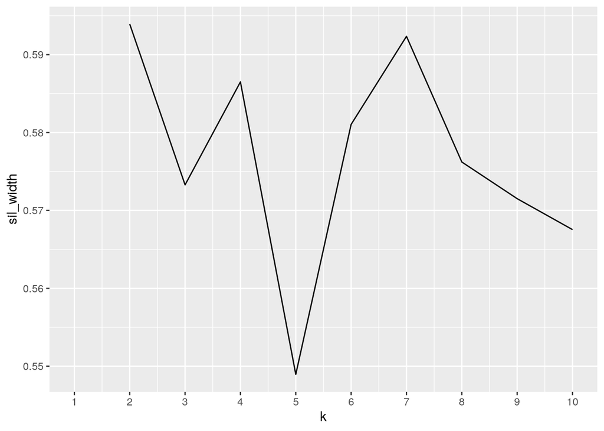

```r
library(cluster)
# clustering code here

clust_dat <- moviejoin %>% select(Num..Votes, You.rated, Runtime.x)

sil_width <- vector()

for (i in 2:10) {
    kms <- kmeans(clust_dat, centers = i)
    sil <- silhouette(kms$cluster, dist(clust_dat))
    sil_width[i] <- mean(sil[, 3])
}

ggplot() + geom_line(aes(x = 1:10, y = sil_width)) + scale_x_continuous(name = "k",
    breaks = 1:10)
```

```r
pam <- clust_dat %>% pam(k = 2)
pam
```

```
## Medoids:
##        ID Num..Votes You.rated Runtime.x
## [1,] 4304     311872         7       109
## [2,] 1989     108968         5       130
## Clustering vector:
##   [1] 1 1 1 1 2 1 1 1 1 1 1 1 1 1 1 1 1 1 1 1 1 1 1 1 1 1 1 1 1 1 1 1 1 1 1 1 1
##  [38] 1 1 1 1 1 1 1 1 1 1 1 1 1 1 2 2 2 2 2 2 2 2 2 2 2 2 2 2 2 2 2 2 2 2 2 2 2
##  [75] 2 2 2 2 2 2 2 1 1 1 1 1 1 1 1 1 1 1 1 1 1 1 1 1 1 1
##  [ reached getOption("max.print") -- omitted 5200 entries ]
## Objective function:
##    build     swap
## 83380.12 73270.95
##
## Available components:
##  [1] "medoids"    "id.med"     "clustering" "objective"  "isolation"
##  [6] "clusinfo"   "silinfo"    "diss"       "call"       "data"
```

```r
pam$silinfo$avg.width
```

```
## [1] 0.5627543
```

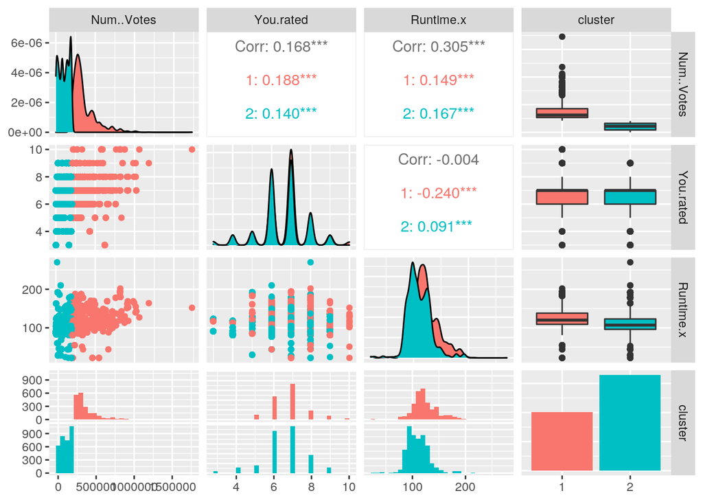

```r
library(GGally)
clust_dat <- clust_dat %>% ungroup %>% mutate(cluster = as.factor(pam$clustering))

ggpairs(clust_dat, aes(color = cluster))
```

The variables that we looked at for this cluster were Num..Votes, You.rated,and Runtime. Based on the average silhouette length we chose to use a value of 2 for the number of clusters used. If we look at both the clusteres there seems to very very few differences in their values. We can see that the Red cluster seems to have a higer Num..Votes value were as the You.Rated and Runtime values are very similar. This could mean the the red cluster is representing the number of votes where as the blue cluster is representing the runtime of the movies. There seems to be a very big overlap in the individual ratings (You Rated) and the Runtime of the clusters. This result makes sense since the values for those variables are relativity consistent as seen in project 1. The average silhouette width suggestes that we need an average of 0.56. This value suggests that a reasonable structure was identified.

### Dimensionality Reduction with PCA

```r
# PCA code here

PCAMoviejoin <- moviejoin %>% select(IMDb.Rating, Num..Votes,
    Runtime.x)

pcaMovieData <- princomp(PCAMoviejoin, cor = T)
scaledability <- data.frame(scale(PCAMoviejoin))
summary(pcaMovieData, loadings = "T")
```

```
## Importance of components:
##                          Comp.1    Comp.2    Comp.3
## Standard deviation     1.281617 0.9181523 0.7172547
## Proportion of Variance 0.547514 0.2810012 0.1714848
## Cumulative Proportion  0.547514 0.8285152 1.0000000
##
## Loadings:
##             Comp.1 Comp.2 Comp.3
## IMDb.Rating  0.595  0.511  0.620
## Num..Votes   0.651  0.145 -0.745
## Runtime.x    0.470 -0.847  0.246
```

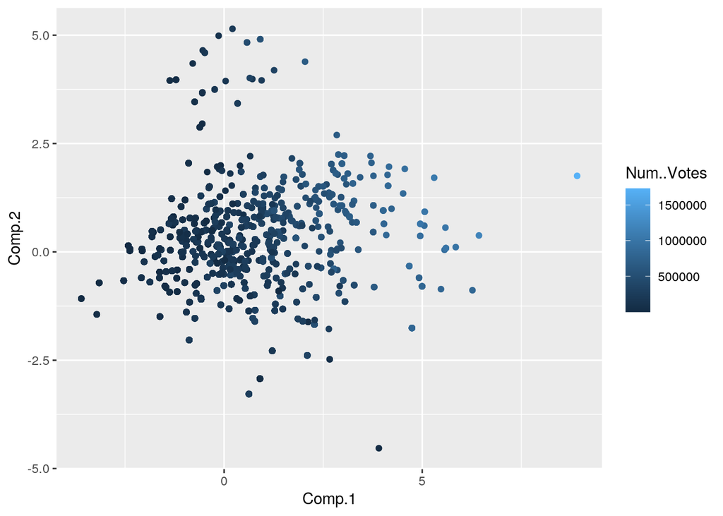

```r
matrix <- pcaMovieData$scores
matrix <- matrix %>% as.data.frame() %>% mutate(Num..Votes = PCAMoviejoin$Num..Votes)
ggplot(matrix, aes(Comp.1, Comp.2)) + geom_point(aes(color = Num..Votes))
```

```r
cor(PCAMoviejoin$Num..Votes, matrix$Comp.1)
```

```
## [1] 0.8348021
```

### Linear Classifier

```r
# linear classifier code here

log_fit <- glm(EnglishorNot ~ Runtime.x + Runtime.y + Num..Votes +
    You.rated + Year + IMDb.Rating, data = moviejoin, family = "binomial")

prob_reg <- predict(log_fit)

class_diag(prob_reg, moviejoin$EnglishorNot, positive = 1)
```

```
##            acc   sens  spec  ppv     f1     ba    auc
## Metrics 0.7021 0.9355 0.084 0.73 0.8201 0.5097 0.6023
```

```r
# cross-validation of linear classifier here


set.seed(400)
k = 10

data <- sample_frac(moviejoin)
folds <- rep(1:k, length.out = nrow(data))

diags <- NULL

i = 1
for (i in 1:k) {

    train <- data[folds != i, ]
    test <- data[folds == i, ]
    truth <- test$EnglishorNot


    fit <- glm(EnglishorNot ~ Runtime.x + Runtime.y + Num..Votes +
        You.rated + Year + IMDb.Rating, data = train, family = "binomial")


    probs <- predict(fit, test)  ### GET PREDICTIONS FROM THE TRAINED MODEL ON THE TEST SET HERE


    diags <- rbind(diags, class_diag(probs, truth, positive = 1))
}

summarize_all(diags, mean)
```

```
##       acc    sens    spec     ppv      f1     ba     auc
## 1 0.70132 0.93507 0.08374 0.72993 0.81947 0.5094 0.59888
```

### Non-Parametric Classifier

```r
library(caret)
# non-parametric classifier code here


knn_fit <- knn3(EnglishorNot ~ Runtime.x + Runtime.y + Num..Votes +
    You.rated + Year + IMDb.Rating, data = moviejoin)

prob_knn <- predict(knn_fit, moviejoin)

class_diag(prob_knn[, 2], moviejoin$EnglishorNot, positive = 1)
```

```
##            acc   sens   spec   ppv     f1     ba    auc
## Metrics 0.7672 0.9212 0.3593 0.792 0.8517 0.6402 0.7782
```

```r
# cross-validation of np classifier here


set.seed(400)
k = 10

data <- sample_frac(moviejoin)
folds <- rep(1:k, length.out = nrow(data))

diags <- NULL

i = 1
for (i in 1:k) {

    train <- data[folds != i, ]
    test <- data[folds == i, ]
    truth <- test$EnglishorNot

    fit <- knn3(EnglishorNot ~ Runtime.x + Runtime.y + Num..Votes +
        You.rated + Year + IMDb.Rating, data = train)

    probs <- predict(fit, newdata = test)[, 2]

    diags <- rbind(diags, class_diag(probs, truth, positive = 1))
}

summarize_all(diags, mean)
```

```
##       acc    sens    spec     ppv     f1      ba     auc
## 1 0.66265 0.84136 0.19002 0.73316 0.7833 0.51569 0.50735
```

### Regression/Numeric Prediction

```r
# regression model code here

fit <- lm(IMDb.Rating ~ Runtime.x + Runtime.y + Num..Votes +
    You.rated + Year, data = moviejoin)

yhat <- predict(fit)
cbind(yhat, y = moviejoin$IMDb.Rating)
```

```
##          yhat   y
## 1    7.453936 7.9
## 2    7.473145 7.9
## 3    7.481233 7.9
## 4    7.469101 7.9
## 5    6.821315 8.0
## 6    7.095265 6.7
## 7    7.114474 6.7
## 8    7.089199 6.7
## 9    7.086166 6.7
## 10   7.096276 6.7
## 11   7.090716 6.7
## 12   7.088694 6.7
## 13   7.087683 6.7
## 14   7.101837 6.7
```

[output cut: 37 more lines]

```r
mean((moviejoin$IMDb.Rating - yhat)^2)
```

```
## [1] 0.2084545
```

```r
# cross-validation of regression model here

set.seed(1200)
k = 5

data <- moviejoin[sample(nrow(moviejoin)), ]
folds <- cut(seq(1:nrow(moviejoin)), breaks = k, labels = F)

diags <- NULL
for (i in 1:k) {
    train <- data[folds != i, ]
    test <- data[folds == i, ]

    fit <- lm(IMDb.Rating ~ Runtime.x + Runtime.y + Num..Votes +
        You.rated + Year, data = train)

    yhat <- predict(fit, newdata = test)

    diags <- mean((test$IMDb.Rating - yhat)^2)
}

mean(diags)
```

```
## [1] 0.2331971
```

Discussion

The linear regression resulted in a MSE of 0.208. This value is great and suggests our prediction error is very small. When compared to the CV, the resulted MSE value of 0.2331 suggests very small prediction error as well.

### Python

```r
library(reticulate)

use_python("/usr/bin/python3", required = F)
Netflix <- "Netflix is"
cat(c(Netflix, py$great))
```

```
## Netflix is
```

```python
# python code here

great = 'Great!'
print(r.Netflix, great)
```

```
## Netflix is Great!
```

I really enjoyed this class and I hope you have a great winter break! Thank You Dr.Woodward and TA’s!